# Project: Monocular Depth Estimation

[figure not shown]

## Introduction

- In this project you are tasked to create a model that **estimates depth from a single input image**. The input is an RGB image and the output is a single channel dense depth map where each pixel is the estimated distance from the 'camera sensor' to an object in the scene in real world units (e.g. in meters). Depth from a single image is a fundemental vision task with many useful applications including scene understanding and reconstruction.
- You are to develop a convolutional neural network (CNN) that formulates the problem as a regression of the depth map from a single RGB image. You can find many papers and code related to this problem [here](https://paperswithcode.com/task/monocular-depth-estimation).
- In the following, we provide all the source code needed for loading and evaluating your model.
- Your task in this project is to modify the script in order to:
  - Define a [UNet](https://arxiv.org/abs/1505.04597) model that takes an RGB image and outputs a single channel depth map. **[50 points]**
  - Define an approprate loss function. **[25 points]**
  - Tune the model to achieve an RMSE of **0.035** or less on the given validation set. **[25 points]**

**Note**: Make sure that your Collab notebook is a GPU instance. Also, the first time you run the training, the instance might crash for exceeding the allocated memory. This is expected behaviour, especially with large batch sizes. Collab will suggest restarting the session and providing instances with larger memory sizes.

**Note**: This project is more open-ended than the previous projects. Multiple solutions can be considered *correct*. As there already exist implementations of various deep networks for this task on the interwebs, **plagiarism will NOT be tolerated**. Your code will be judged for similarity against code available online and other students' code. You are expected to justify every design decision when your project is being evaluated.

**Note**: The networks you will design/implement will be much larger than what you have previously designed. Please bring hardware concerns to the attention of the TA. You will need to begin early to test out new ideas/hyperparameters and training will take much longer. Best of luck!

## Downloading Data

Run the following cell to download the dataset and extract the zip archive.

If you are not running a Linux/Mac machine. Please download the following zip file manually and extract it in the same directory as the notebook.

```python
! wget -nc https://densedepth2019.s3.amazonaws.com/UnrealData256.zip
! unzip -nq UnrealData256.zip
```

```
File ‘UnrealData256.zip’ already there; not retrieving.
```

## Hyperparameters

You are supposed to change the batch_size and learning_rate from their default value.

```python
import os
import gc
import time
import datetime

os.environ["CUDA_VISIBLE_DEVICES"] = "0"

epochs = 10
batch_size = 25
learning_rate = 0.00005
workers = 16 # The number of parallel processes used to read data
gpu_id = [0] # only modify if you machine has more than one GPU card
```

```python
%pwd
```

```
'/home/gasanoe/KAUST_CS390DD_DeepLearning/depth-estimation'
```

## Data Loader (no tasks required)

```python
if __name__ == '__main__':
    import torch.multiprocessing as mp
    from loaders import prep_loaders
    train_loader, valid_loader = prep_loaders('UnrealData256', batch_size=batch_size, workers=workers)
```

```
Dataset size (num. batches) 1015 21
```

## Sanity check

```
torch.Size([25, 3, 256, 256]) torch.Size([25, 1, 128, 128])
```

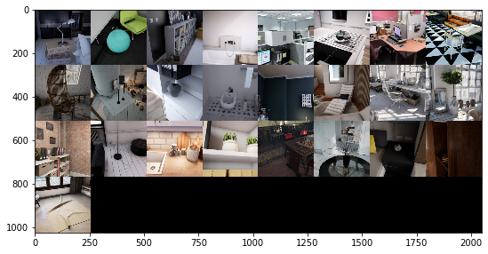

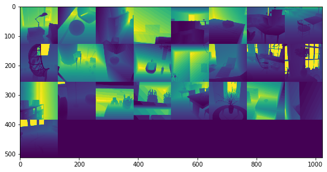

```python
# Examine training data
%pylab inline
import torchvision
sample = iter(train_loader).next()
print(sample['image'].shape, sample['depth'].shape)
figure(figsize=(9,9)); imshow(torchvision.utils.make_grid(sample['image'], padding=0).permute((1, 2, 0)))
figure(figsize=(9,9)); imshow(torchvision.utils.make_grid(sample['depth'], padding=0, normalize=True, scale_each=True).permute((1, 2, 0))[:,:,0])
```

## Model [50 points]

Define your model here. The current model is going to perform very poorly on the task. But it will be fast. You are welcome to run it.

```python
import torch
```

```python
device = torch.device("cuda" if torch.cuda.is_available() else "cpu")
```

```python
pretr_mdl = torchvision.models.resnet152(pretrained=True, progress=True).to(device)
```

```python
pretr_mdl
```

[output not shown]

[output cut: 427 more lines]

[output not shown]

```python
import torch.nn as nn

class Identity(nn.Module):
    def __init__(self):
        super(Identity, self).__init__()

    def forward(self, x):
        return x
```

```python
pretr_mdl.avgpool = Identity()
pretr_mdl.fc = Identity()
```

```python
class Encoder(nn.Module):
    def __init__(self, pretrained_model, intermediate_layers):
        super(Encoder, self).__init__()
        self.prt_mdl = pretrained_model
        self.intm_layers = intermediate_layers

    def forward(self, x):
        output = []
        for name, layer in self.prt_mdl._modules.items():
            x = layer(x)
            if name in self.intm_layers:
                output.append(x)
        return output
```

```python
feat_layers = ['conv1', 'layer1', 'layer2', 'layer3', 'layer4']
```

```python
example_enc = Encoder(pretr_mdl, feat_layers)
```

```python
feats = example_enc(sample['image'][0].unsqueeze(0).float().to(device))
```

```python
for feat in feats:
    print(feat.shape)
```

```
torch.Size([1, 64, 128, 128])
torch.Size([1, 256, 64, 64])
torch.Size([1, 512, 32, 32])
torch.Size([1, 1024, 16, 16])
torch.Size([1, 2048, 8, 8])
```

```python
import torch.nn.functional as F

class U_Net_building_block(nn.Module):
    def __init__(self, decoder_in, encoder_in, decoder_out):
        super(U_Net_building_block, self).__init__()
        self.enc_conv = nn.Conv2d(encoder_in, decoder_out // 2, kernel_size=3, padding=1)
        self.upsample = nn.Upsample(scale_factor=2, mode='bilinear')
        self.dec_conv = nn.Conv2d(decoder_in, decoder_out // 2, kernel_size=1)
        self.bn = nn.BatchNorm2d(decoder_out)

    def forward(self, x, feat):
        enc_frw = self.enc_conv(feat)
        x = self.upsample(x)
        dec_frw = self.dec_conv(x)
        concat = torch.cat((enc_frw, dec_frw), dim=1)
        out = self.bn(F.relu(concat))

        return out
```

```python
class Decoder(nn.Module):
    def __init__(self):
        super(Decoder, self).__init__()
        self.unet1 = U_Net_building_block(2048, 1024, 1024)
        self.unet2 = U_Net_building_block(1024, 512, 512)
        self.unet3 = U_Net_building_block(512, 256, 256)
        self.unet4 = U_Net_building_block(256, 64, 32)
        self.conv = nn.Conv2d(32, 1, kernel_size=1)

    def forward(self, x, feature_maps):
        x = self.unet1(x, feature_maps[3])
        x = self.unet2(x, feature_maps[2])
        x = self.unet3(x, feature_maps[1])
        x = self.unet4(x, feature_maps[0])
        x = F.relu(self.conv(x))

        return x
```

```python
class Model(nn.Module):
    def __init__(self):
        super(Model, self).__init__()
        self.encoder = Encoder(pretr_mdl, feat_layers)
        self.decoder = Decoder()

    def forward(self, x):
        enc_output = self.encoder(x)
        feature_maps = enc_output[:-1]
        x = enc_output[-1]
        output = self.decoder(x, feature_maps)

        return output

def create_model_gpu():
    model = Model()
    model = model.cuda()
    model = nn.DataParallel(model, device_ids=[g for g in gpu_id])
    return model

model = create_model_gpu()
print('Ready to train.')

#model.load_state_dict(torch.load('trained_model.pkl'))
```

```
Ready to train.
```

## Loss Function [25 points]

Define a loss function that is suitable for the dense regression task. Why will the current loss not work? Submit the answer in the notebook.

```python
import torch
from math import exp
import torch.nn.functional as F


def loss_fn(pred_y, y):
    batch_size = y.size()[0]
    return torch.sum((y - pred_y) ** 2) / batch_size
```

## Training + Evaluation [25 points]

Tune the hyperparameters and the architecture to achieve the target RMSE

```python
import warnings
warnings.filterwarnings("ignore")
```

```python
optimizer = torch.optim.Adam(model.parameters(), lr=learning_rate)

class RMSE(object):
    def __init__(self):
        self.sq_errors = []
        self.num_pix = 0

    def get(self):
        return np.sqrt(
                    np.sum(np.array(self.sq_errors))/self.num_pix
                )

    def add_batch(self, pred, target):
        sqe = (pred-target)**2
        self.sq_errors.append(np.sum(sqe))
        self.num_pix += target.size

    def reset(self):
        self.sq_errors = []
        self.num_pix = 0


# Used to keep track of statistics
class AverageMeter(object):
    def __init__(self):
        self.val = 0; self.avg = 0; self.sum = 0; self.count = 0
    def update(self, val, n=1):
        self.val = val
        self.sum += val * n
        self.count += n
        self.avg = self.sum / self.count

REPORTS_PER_EPOCH = 10
ITER_PER_EPOCH = len(train_loader)
ITER_PER_REPORT = ITER_PER_EPOCH//REPORTS_PER_EPOCH

metrics = RMSE()

def train(optimizer, epochs):
    run_id = 'model_gpu{}_n{}_bs{}_lr{}'.format(gpu_id, epochs, batch_size, learning_rate); print('\n\nTraining', run_id)
    save_path = run_id + '.pkl'


    for epoch in range(epochs):
        model.train()

        # Progress reporting
        batch_time = AverageMeter()
        losses = AverageMeter()
        N = len(train_loader)
        end = time.time()

        for i, (sample) in enumerate(train_loader):

            # Load a batch and send it to GPU
            x = sample['image'].float().cuda()
            y = sample['depth'].float().cuda()

            # Forward pass: compute predicted y by passing x to the model.
            y_pred = model(x)

            # Compute and print loss.
            loss = loss_fn(y_pred, y)

            # Record loss
            losses.update(loss.data.item(), x.size(0))

            # Before the backward pass, use the optimizer object to zero all of the
            # gradients for the variables it will update (which are the learnable
            # weights of the model).
            optimizer.zero_grad()

            # Backward pass: compute gradient of the loss with respect to model parameters
            loss.backward()

            # Calling the step function on an Optimizer makes an update to its parameters
            optimizer.step()

            # Measure elapsed time
            batch_time.update(time.time() - end)
            end = time.time()
            eta = str(datetime.timedelta(seconds=int(batch_time.val*(N - i))))

            # Log training progress
            if i % ITER_PER_REPORT == 0:
                print('\nEpoch: [{0}][{1}/{2}]\t' 'Time {batch_time.val:.3f} ({batch_time.sum:.3f})\t' 'ETA {eta}\t'
                 'Training Loss {loss.val:.4f} ({loss.avg:.4f})'.format(epoch, i, N, batch_time=batch_time, loss=losses, eta=eta))
            elif i % (ITER_PER_REPORT//50) == 0:
                print('.', end='')

            #break # useful for quick debugging
        torch.cuda.empty_cache(); del x, y; gc.collect()

        # Validation after each epoch
        model.eval()
        metrics.reset()
        for i, (sample) in enumerate(valid_loader):
            x, y = sample['image'].float().cuda(), sample['depth'].float().numpy()
            with torch.no_grad():
                y_pred = model(x).detach().cpu().numpy()

            metrics.add_batch(y_pred, y)
            print('_', end='')
        print('\nValidation RMSE {avg_rmse}'.format(avg_rmse=metrics.get()))


    # Save model
    torch.save(model.state_dict(), save_path)
    print('\nTraining done. Model saved ({}).'.format(save_path))
```

```python
train(optimizer, epochs)
```

```
Training model_gpu[0]_n10_bs25_lr5e-05

Epoch: [0][0/1015]	Time 1.212 (1.212)	ETA 0:20:30	Training Loss 2836.1328 (2836.1328)
..................................................
Epoch: [0][101/1015]	Time 0.487 (50.494)	ETA 0:07:25	Training Loss 415.7499 (746.7385)
..................................................
Epoch: [0][202/1015]	Time 0.494 (100.066)	ETA 0:06:41	Training Loss 331.8283 (575.0233)
..................................................
Epoch: [0][303/1015]	Time 0.490 (150.220)	ETA 0:05:48	Training Loss 301.1112 (478.3288)
..................................................
Epoch: [0][404/1015]	Time 0.493 (201.123)	ETA 0:05:01	Training Loss 200.4335 (417.7587)
..................................................
Epoch: [0][505/1015]	Time 0.509 (252.096)	ETA 0:04:19	Training Loss 176.3156 (374.8753)
..................................................
Epoch: [0][606/1015]	Time 0.519 (304.048)	ETA 0:03:32	Training Loss 182.7776 (342.1119)
..................................................
Epoch: [0][707/1015]	Time 0.507 (355.744)	ETA 0:02:36	Training Loss 140.4147 (316.3762)
..................................................
Epoch: [0][808/1015]	Time 0.495 (407.749)	ETA 0:01:42	Training Loss 109.2146 (294.9070)
..................................................
Epoch: [0][909/1015]	Time 0.522 (459.788)	ETA 0:00:55	Training Loss 136.7565 (277.1998)
..................................................
Epoch: [0][1010/1015]	Time 0.507 (511.672)	ETA 0:00:02	Training Loss 164.5439 (262.8129)
.._____________________
Validation RMSE 0.08206907544522864

Epoch: [1][0/1015]	Time 1.264 (1.264)	ETA 0:21:22	Training Loss 102.1749 (102.1749)
..................................................
Epoch: [1][101/1015]	Time 0.510 (52.972)	ETA 0:07:45	Training Loss 102.7512 (116.9869)
..................................................
Epoch: [1][202/1015]	Time 0.494 (105.417)	ETA 0:06:41	Training Loss 285.6953 (116.0272)
..................................................
Epoch: [1][303/1015]	Time 0.524 (157.371)	ETA 0:06:13	Training Loss 101.8130 (116.1443)
..................................................
Epoch: [1][404/1015]	Time 0.516 (209.387)	ETA 0:05:15	Training Loss 78.5833 (113.9852)
..................................................
Epoch: [1][505/1015]	Time 0.516 (261.472)	ETA 0:04:23	Training Loss 142.9246 (110.8356)
..................................................
Epoch: [1][606/1015]	Time 0.496 (313.195)	ETA 0:03:22	Training Loss 80.9656 (107.4244)
..................................................
```

[output cut: 188 more lines]

```
Epoch: [9][505/1015]	Time 0.501 (256.738)	ETA 0:04:15	Training Loss 15.1403 (18.8371)
..................................................
Epoch: [9][606/1015]	Time 0.535 (307.880)	ETA 0:03:38	Training Loss 20.0552 (19.5778)
..................................................
Epoch: [9][707/1015]	Time 0.499 (359.212)	ETA 0:02:33	Training Loss 22.6126 (21.2360)
..................................................
Epoch: [9][808/1015]	Time 0.509 (410.327)	ETA 0:01:45	Training Loss 24.6946 (22.8487)
..................................................
Epoch: [9][909/1015]	Time 0.502 (461.534)	ETA 0:00:53	Training Loss 23.7636 (23.3755)
..................................................
Epoch: [9][1010/1015]	Time 0.524 (512.719)	ETA 0:00:02	Training Loss 25.0118 (23.4574)
.._____________________
Validation RMSE 0.03783440868772849

Training done. Model saved (model_gpu[0]_n10_bs25_lr5e-05.pkl).
```

```python
model.load_state_dict(torch.load('model_gpu[0]_n10_bs25_lr5e-05.pkl'))
```

```
<All keys matched successfully>
```

```python
learning_rate = 0.00001
epochs = 2
optimizer = torch.optim.Adam(model.parameters(), lr=learning_rate)
torch.cuda.empty_cache()

train(optimizer, epochs)
```

```
Training model_gpu[0]_n2_bs25_lr1e-05

Epoch: [0][0/1015]	Time 1.289 (1.289)	ETA 0:21:48	Training Loss 17.5681 (17.5681)
..................................................
Epoch: [0][101/1015]	Time 0.474 (49.740)	ETA 0:07:13	Training Loss 9.8623 (18.9932)
..................................................
Epoch: [0][202/1015]	Time 0.479 (98.448)	ETA 0:06:29	Training Loss 13.6478 (17.8208)
..................................................
Epoch: [0][303/1015]	Time 0.487 (147.411)	ETA 0:05:46	Training Loss 24.8175 (17.4974)
..................................................
Epoch: [0][404/1015]	Time 0.487 (196.533)	ETA 0:04:57	Training Loss 16.2538 (17.3072)
..................................................
Epoch: [0][505/1015]	Time 0.485 (246.058)	ETA 0:04:07	Training Loss 14.3255 (17.1145)
..................................................
Epoch: [0][606/1015]	Time 0.490 (296.135)	ETA 0:03:20	Training Loss 9.6486 (16.9381)
..................................................
Epoch: [0][707/1015]	Time 0.525 (346.171)	ETA 0:02:41	Training Loss 15.1951 (16.7067)
..................................................
Epoch: [0][808/1015]	Time 0.489 (396.226)	ETA 0:01:41	Training Loss 7.3904 (16.4904)
..................................................
Epoch: [0][909/1015]	Time 0.496 (446.108)	ETA 0:00:52	Training Loss 8.8955 (16.3537)
..................................................
Epoch: [0][1010/1015]	Time 0.486 (495.732)	ETA 0:00:02	Training Loss 14.4598 (16.1667)
.._____________________
Validation RMSE 0.032782330313518

Epoch: [1][0/1015]	Time 1.176 (1.176)	ETA 0:19:53	Training Loss 12.5401 (12.5401)
..................................................
Epoch: [1][101/1015]	Time 0.484 (51.281)	ETA 0:07:22	Training Loss 14.5347 (15.1499)
..................................................
Epoch: [1][202/1015]	Time 0.490 (101.439)	ETA 0:06:38	Training Loss 31.1834 (15.0396)
..................................................
Epoch: [1][303/1015]	Time 0.501 (151.882)	ETA 0:05:56	Training Loss 14.7936 (14.7427)
..................................................
Epoch: [1][404/1015]	Time 0.500 (202.039)	ETA 0:05:05	Training Loss 10.6078 (14.6071)
..................................................
Epoch: [1][505/1015]	Time 0.492 (252.468)	ETA 0:04:10	Training Loss 21.1115 (14.4221)
..................................................
Epoch: [1][606/1015]	Time 0.509 (303.162)	ETA 0:03:28	Training Loss 12.3628 (14.2413)
..................................................
Epoch: [1][707/1015]	Time 0.484 (353.763)	ETA 0:02:29	Training Loss 13.4250 (14.2804)
..................................................
Epoch: [1][808/1015]	Time 0.483 (404.086)	ETA 0:01:39	Training Loss 11.9351 (14.2317)
..................................................
Epoch: [1][909/1015]	Time 0.511 (454.845)	ETA 0:00:54	Training Loss 10.6994 (14.0973)
..................................................
Epoch: [1][1010/1015]	Time 0.514 (505.523)	ETA 0:00:02	Training Loss 10.4615 (14.0177)
.._____________________
Validation RMSE 0.031784814767917245

Training done. Model saved (model_gpu[0]_n2_bs25_lr1e-05.pkl).
```

## Visual Test of the Trained Model (no tasks required)

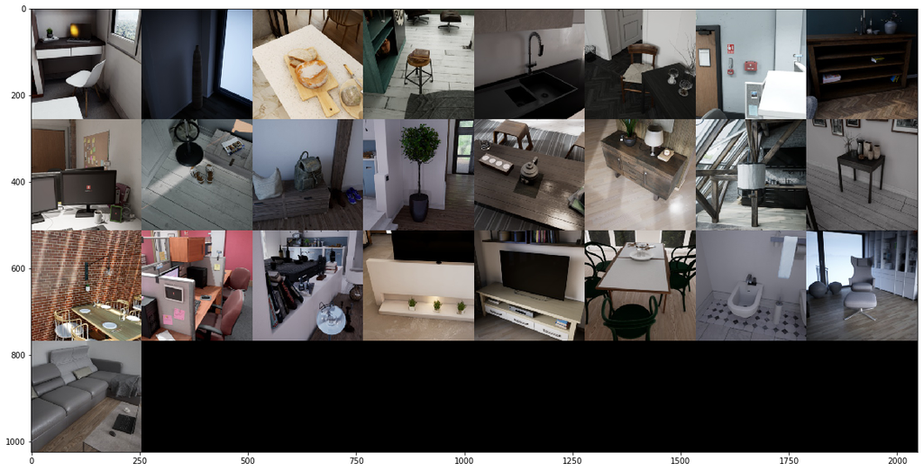

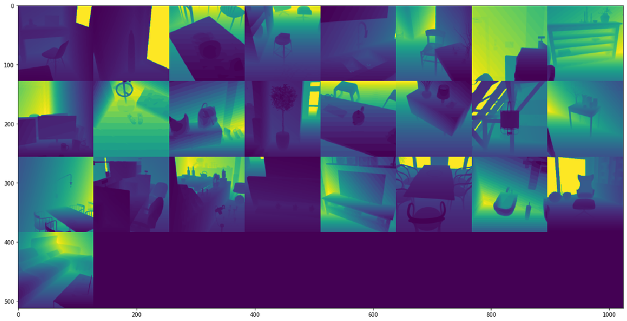

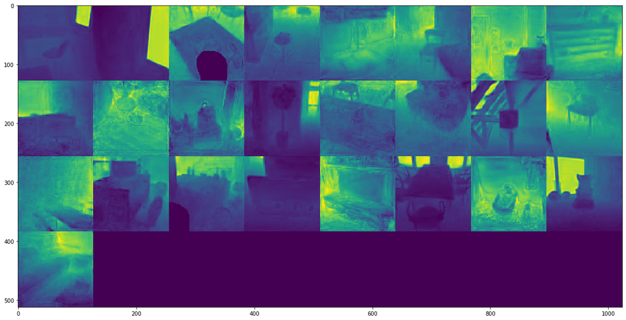

```python
# Load model from disk
#model = create_model_gpu()
#model.load_state_dict(torch.load('trained_model.pkl'))
#model.eval() # set to evaluation mode

# Visualize validation sample
sample = iter(valid_loader).next()
x = sample['image'].float().cuda()
y_pred, y = model(x), sample['depth']

figure(figsize=(20,20)); imshow(torchvision.utils.make_grid(sample['image'], padding=0).permute((1, 2, 0)))
figure(figsize=(20,20)); imshow(torchvision.utils.make_grid(sample['depth'], padding=0, normalize=True, scale_each=True).permute((1, 2, 0))[:,:,0])
figure(figsize=(20,20)); imshow(torchvision.utils.make_grid(y_pred.detach().cpu(), padding=0, normalize=True, scale_each=True).permute((1, 2, 0))[:,:,0])
```